# Has friend(s)/confidant

# 1 Description of DataSchema variable

The description of harmonised variable is the following:

- Short name: `confidant`
- Variable label: `Has friend(s)/confident`
- Domain: `Social environment`
- Value type: `categorical`
- Category coding:

| **Code** | **Category Label** |
| --- | --- |
| 0 | No |
| 1 | Yes |

- Category missings:

| **Code** | **Category Label** |
| --- | --- |
| 991 | CAPI/interviewer error |
| 992 | Impute |
| 993 | Disable to measure |
| 994 | Not attempt/not done |
| 995 | Does not answer |
| 996 | Not applicable |
| 997 | Refuse |
| 998 | Do not know |
| 999 | Missing |

# 2 Data process

## 2.1 England

### 2.1.1 Wave 1

#### 2.1.1.1 Study-specific variable description

- Name: `scfrd`
- Label: `do you have any friends`
- Categories:
  - `1.0 = Yes`
  - `2.0 = No`
- Missings:
  - `-9.0 = Not answered`
  - `-1.0 = Item not applicable`
- Description:

| Sample size | Missing values |
| --- | --- |
| 12099 | 1484 |

Category

|  | 1 | 2 |
| --- | --- | --- |
| Frequency | 10041.00 | 574.00 |
| Percentage | 82.99 | 4.74 |

Type of missing

|  | -1 | -9 | NA |
| --- | --- | --- | --- |
| Frequency | 1108.00 | 376.00 | 0 |
| Percentage | 9.16 | 3.11 | 0 |

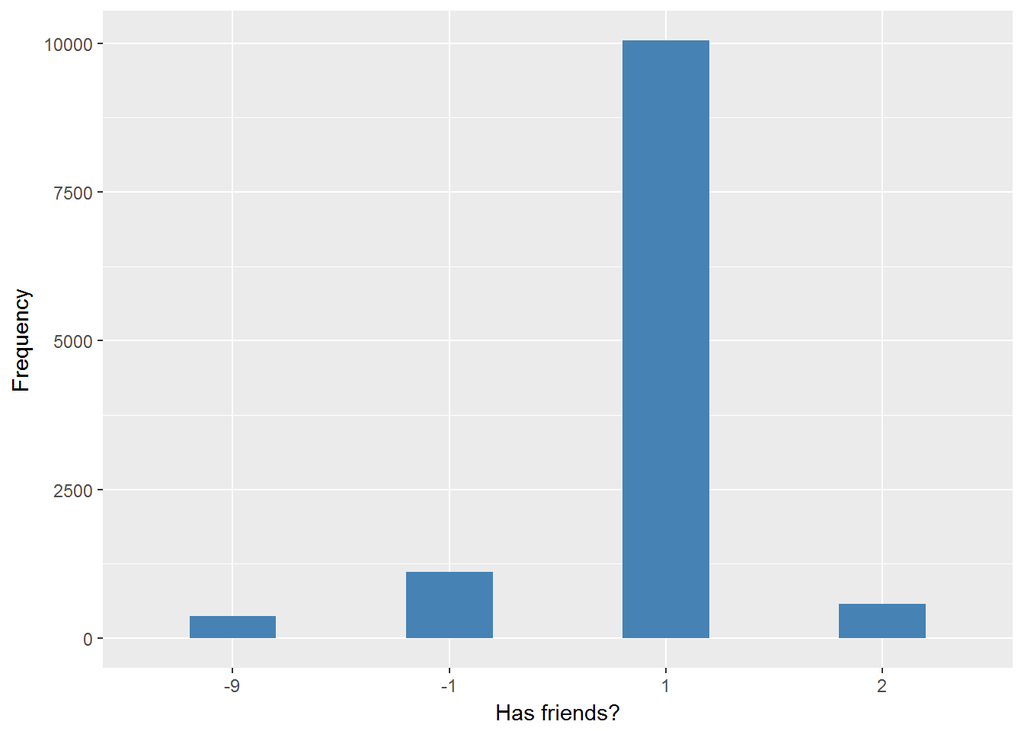

#### 2.1.1.2 Harmonisation algorithm

To compute the harmonize variable from the study-specific variable it has to be recoded as follows:

- `1 Yes into 1`
- `2 No into 0`
- `-1 Item not applicable into 996`
- `-9 Not answered into 995`
- `NA into 999`

**R script:**

```r
ELSA_ds_w1 <- tibble(id = ELSA_w1_confidant$id)
ELSA_ds_w1$confidant <- car::recode(as.vector(ELSA_w1_confidant$scfrd), "1='1'; 2='0'; -1='996'; -9='995'; NA='999'")
ELSA_ds_w1$confidant <- labelled(ELSA_ds_w1$confidant, labels = c(No = 0, Yes = 1,
    Missing = 999, `Do not know` = 998, Refuse = 997, `Not applicable` = 996,
    `Don't answer` = 995, `Not attempt/not done/not yet recorded` = 994, `Disable to measure` = 993,
    Impute = 992, `CAPI/interviewer error` = 991))
```

#### 2.1.1.3 Statistical description of the new harmonised variable

| Sample size | Missing values |
| --- | --- |
| 12099 | 1484 |

Category

|  | 0 | 1 |
| --- | --- | --- |
| Frequency | 574.00 | 10041.00 |
| Percentage | 4.74 | 82.99 |

Type of missing

|  | 991 | 992 | 993 | 994 | 995 | 996 | 997 | 998 | 999 | NA |
| --- | --- | --- | --- | --- | --- | --- | --- | --- | --- | --- |
| Frequency | 0 | 0 | 0 | 0 | 376.00 | 1108.00 | 0 | 0 | 0 | 0 |
| Percentage | 0 | 0 | 0 | 0 | 3.11 | 9.16 | 0 | 0 | 0 | 0 |

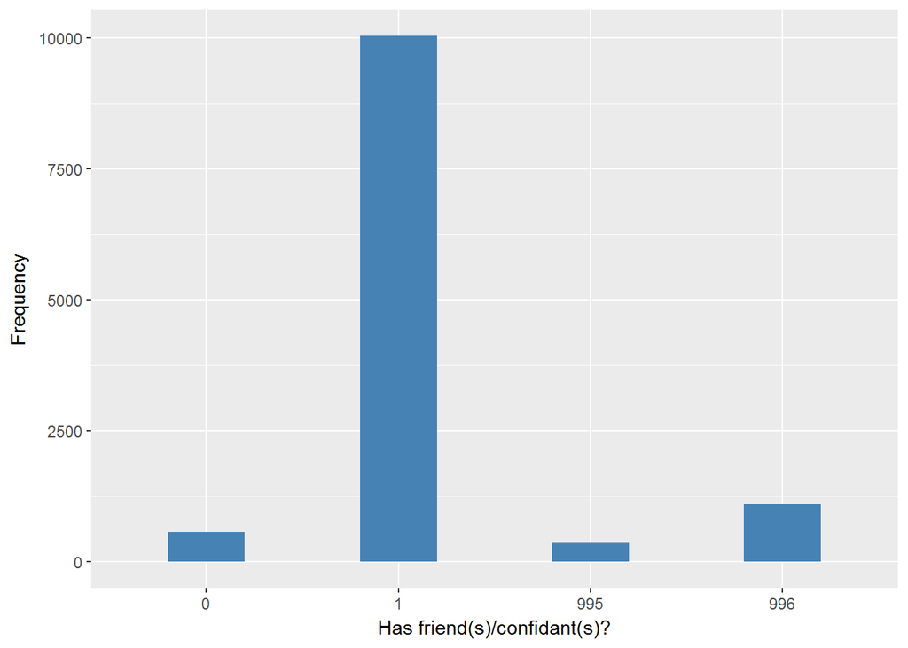

#### 2.1.1.4 Validation

|  | 2->0 | 1 | -9->995 | -1->996 |
| --- | --- | --- | --- | --- |
| BeforeH | 574 | 10041 | 376 | 1108 |
| AfterH | 574 | 10041 | 376 | 1108 |

### 2.1.2 Wave 2

#### 2.1.2.1 Study-specific variable description

- Name: `scfrd`
- Label: `Whether the respondent has any friends`
- Categories:
  - `1.0 = Yes`
  - `2.0 = No`
- Missings:
  - `-9.0 = Not answered`
  - `-1.0 = Item not applicable`
- Description:

| Sample size | Missing values |
| --- | --- |
| 9432 | 1186 |

Category

|  | 1 | 2 |
| --- | --- | --- |
| Frequency | 7857.0 | 389.00 |
| Percentage | 83.3 | 4.12 |

Type of missing

|  | -1 | -9 | NA |
| --- | --- | --- | --- |
| Frequency | 1072.00 | 114.00 | 0 |
| Percentage | 11.37 | 1.21 | 0 |

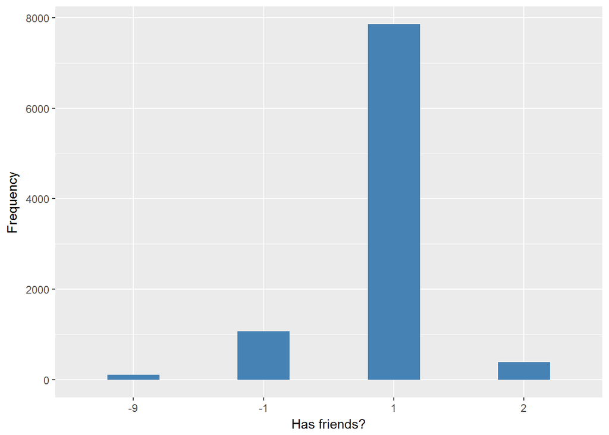

#### 2.1.2.2 Harmonisation algorithm

To recode the harmonize variable from the study-specific variable it has to be recoded as follows:

- `1 Yes into 1`
- `2 No into 0`
- `-1 Item not applicable into 996`
- `-9 Not answered into 995`
- `NA into 999`

**R script:**

```r
ELSA_ds_w2 <- tibble(id = ELSA_w2_confidant$id)
ELSA_ds_w2$confidant <- car::recode(as.vector(ELSA_w2_confidant$scfrd), "1='1'; 2='0'; -1='996'; -9='995'; NA='999'")
ELSA_ds_w2$confidant <- labelled(ELSA_ds_w2$confidant, labels = c(No = 0, Yes = 1,
    Missing = 999, `Do not know` = 998, Refuse = 997, `Not applicable` = 996,
    `Don't answer` = 995, `Not attempt/not done/not yet recorded` = 994, `Disable to measure` = 993,
    Impute = 992, `CAPI/interviewer error` = 991))
```

#### 2.1.2.3 Statistical description of the new harmonised variable

| Sample size | Missing values |
| --- | --- |
| 9432 | 1186 |

Category

|  | 0 | 1 |
| --- | --- | --- |
| Frequency | 389.00 | 7857.0 |
| Percentage | 4.12 | 83.3 |

Type of missing

|  | 991 | 992 | 993 | 994 | 995 | 996 | 997 | 998 | 999 | NA |
| --- | --- | --- | --- | --- | --- | --- | --- | --- | --- | --- |
| Frequency | 0 | 0 | 0 | 0 | 114.00 | 1072.00 | 0 | 0 | 0 | 0 |
| Percentage | 0 | 0 | 0 | 0 | 1.21 | 11.37 | 0 | 0 | 0 | 0 |

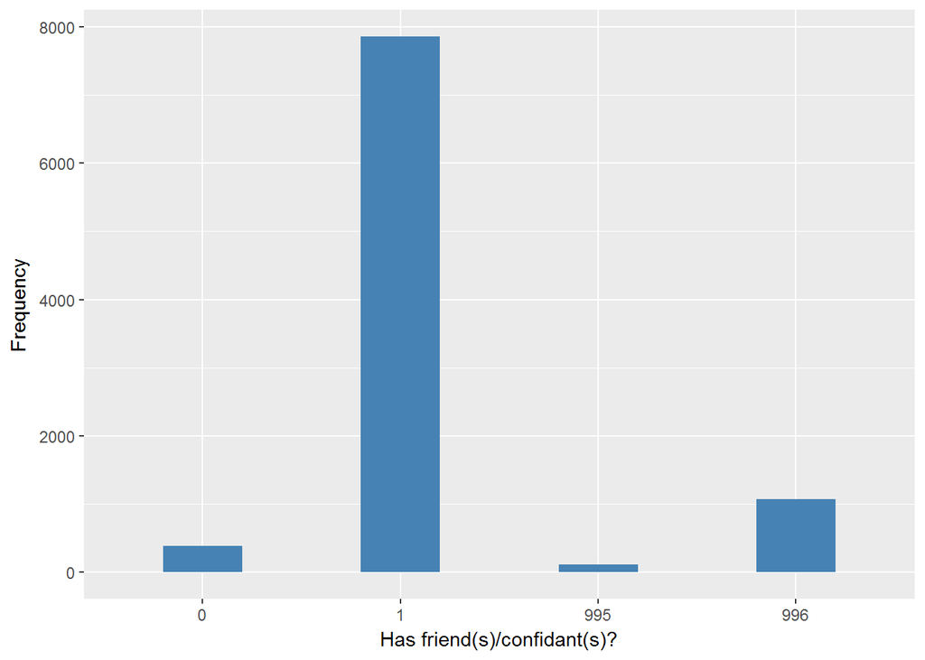

#### 2.1.2.4 Validation

|  | 2->0 | 1 | -9->995 | -1->996 |
| --- | --- | --- | --- | --- |
| BeforeH | 389 | 7857 | 114 | 1072 |
| AfterH | 389 | 7857 | 114 | 1072 |

### 2.1.3 Wave 3

#### 2.1.3.1 Study-specific variable description

- Name: `scfrd`
- Label: `Whether the respondent has any friends`
- Categories:
  - `1.0 = Yes`
  - `2.0 = No`
- Missings:
  - `-1.0 = Item not applicable`
  - `-8.0 = Don't know`
  - `-9.0 = Not answered`
- Description:

| Sample size | Missing values |
| --- | --- |
| 9771 | 1634 |

Category

|  | 1 | 2 |
| --- | --- | --- |
| Frequency | 7735.00 | 402.00 |
| Percentage | 79.16 | 4.11 |

Type of missing

|  | -1 | -8 | -9 | NA |
| --- | --- | --- | --- | --- |
| Frequency | 1527.00 | 0 | 107.0 | 0 |
| Percentage | 15.63 | 0 | 1.1 | 0 |

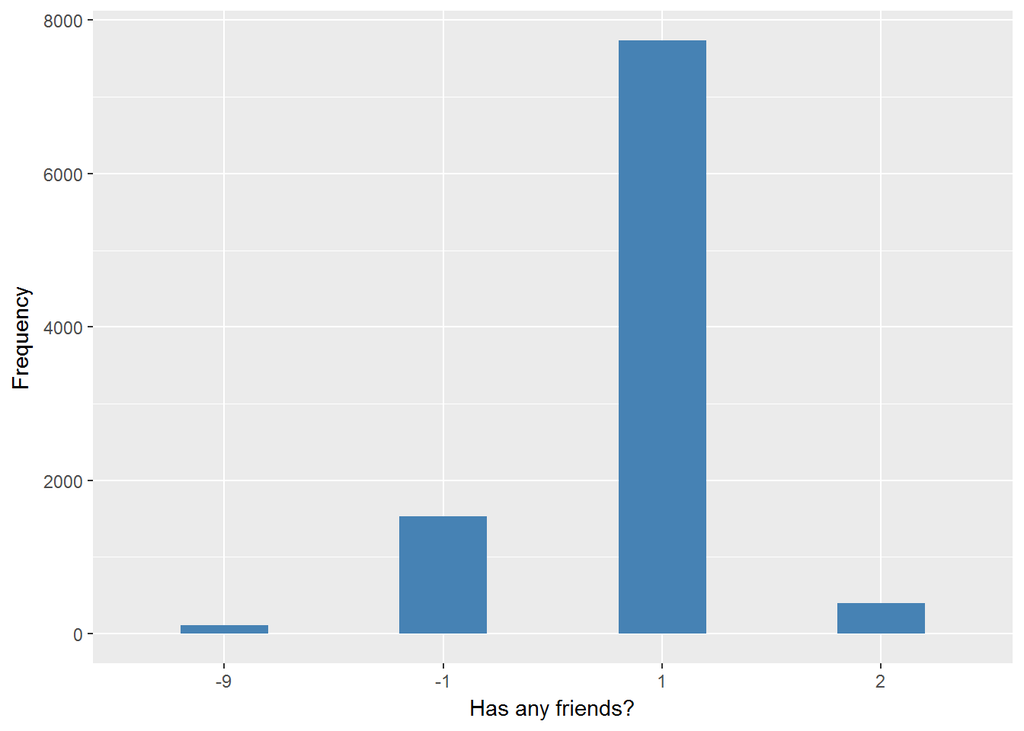

#### 2.1.3.2 Harmonisation algorithm

To recode the harmonize variable from the study-specific variable it has to be recoded as follows:

- `1 Yes into 1`
- `2 No into 0`
- `-1 Item not applicable into 996`
- `-8 Don't Know into 998`
- `-9 Not answered into 995`
- `NA into 999`

**R script:**

```r
ELSA_ds_w3 <- tibble(id = ELSA_w3_confidant$id)
ELSA_ds_w3$confidant <- car::recode(as.vector(ELSA_w3_confidant$scfrd), "1='1'; 2='0';-9='995'; -8='998'; -1='996'; NA='999'")
ELSA_ds_w3$confidant <- labelled(ELSA_ds_w3$confidant, labels = c(No = 0, Yes = 1,
    Missing = 999, `Do not know` = 998, Refuse = 997, `Not applicable` = 996,
    `Don't answer` = 995, `Not attempt/not done/not yet recorded` = 994, `Disable to measure` = 993,
    Impute = 992, `CAPI/interviewer error` = 991))
```

#### 2.1.3.3 Statistical description of the new harmonised variable

| Sample size | Missing values |
| --- | --- |
| 9771 | 1634 |

Category

|  | 0 | 1 |
| --- | --- | --- |
| Frequency | 402.00 | 7735.00 |
| Percentage | 4.11 | 79.16 |

Type of missing

|  | 991 | 992 | 993 | 994 | 995 | 996 | 997 | 998 | 999 | NA |
| --- | --- | --- | --- | --- | --- | --- | --- | --- | --- | --- |
| Frequency | 0 | 0 | 0 | 0 | 107.0 | 1527.00 | 0 | 0 | 0 | 0 |
| Percentage | 0 | 0 | 0 | 0 | 1.1 | 15.63 | 0 | 0 | 0 | 0 |

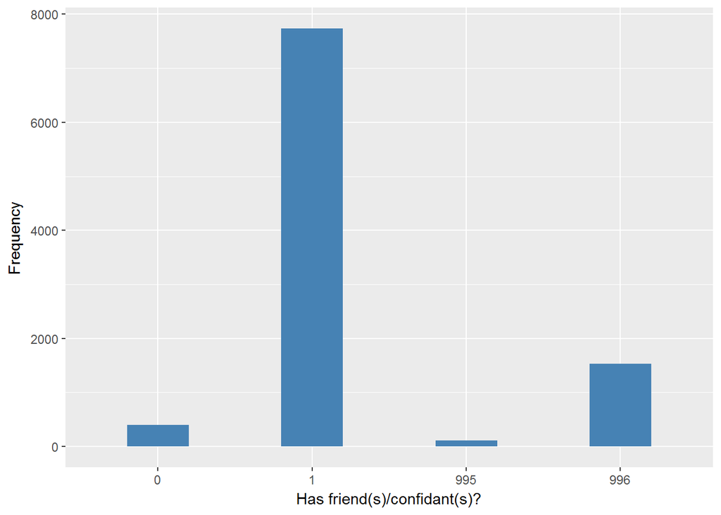

##### 2.1.3.3.1 Validation

|  | 2->0 | 1 | -9->995 | -1->996 |
| --- | --- | --- | --- | --- |
| BeforeH | 402 | 7735 | 107 | 1527 |
| AfterH | 402 | 7735 | 107 | 1527 |

### 2.1.4 Wave 4

#### 2.1.4.1 Study-specific variable description

- Name: `scfrd`
- Label: `Whether the respondent has any friends`
- Categories:
  - `1.0 = Yes`
  - `2.0 = No`
- Missings:
  - `-1.0 = Item not applicable`
  - `-8.0 = Don't know`
  - `-9.0 = Not answered`
- Description:

| Sample size | Missing values |
| --- | --- |
| 11050 | 1823 |

Category

|  | 1 | 2 |
| --- | --- | --- |
| Frequency | 8756.00 | 471.00 |
| Percentage | 79.24 | 4.26 |

Type of missing

|  | -1 | -8 | -9 | NA |
| --- | --- | --- | --- | --- |
| Frequency | 1708.00 | 0 | 115.00 | 0 |
| Percentage | 15.46 | 0 | 1.04 | 0 |

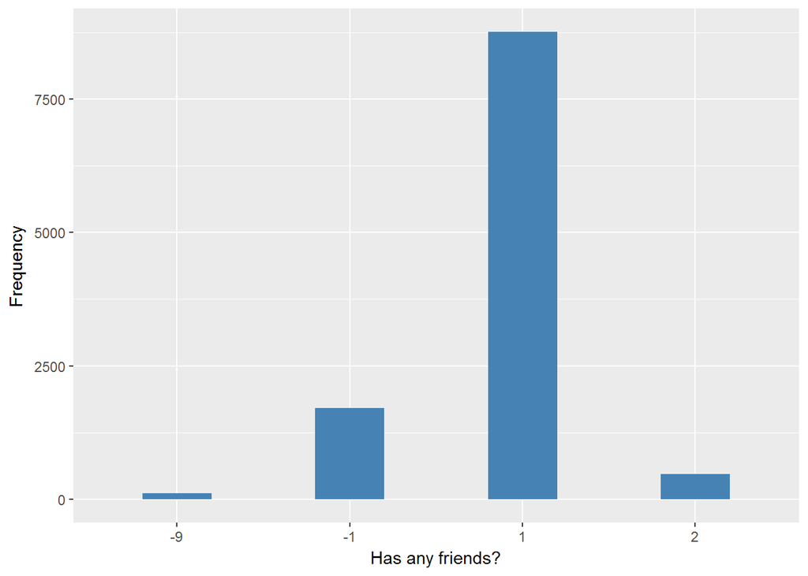

#### 2.1.4.2 Harmonisation algorithm

To recode the harmonize variable from the study-specific variable it has to be recoded as follows:

- `1 Yes into 1`
- `2 No into 0`
- `-1 Item not applicable into 996`
- `-8 Don't Know into 998`
- `-9 Not answered into 995`
- `NA into 999`

**R script:**

```r
ELSA_ds_w4 <- tibble(id = ELSA_w4_confidant$id)
ELSA_ds_w4$confidant <- car::recode(as.vector(ELSA_w4_confidant$scfrd), "1='1'; 2='0';-9='995'; -8='998'; -1='996'; NA='999'")
ELSA_ds_w4$confidant <- labelled(ELSA_ds_w4$confidant, labels = c(No = 0, Yes = 1,
    Missing = 999, `Do not know` = 998, Refuse = 997, `Not applicable` = 996,
    `Don't answer` = 995, `Not attempt/not done/not yet recorded` = 994, `Disable to measure` = 993,
    Impute = 992, `CAPI/interviewer error` = 991))
```

#### 2.1.4.3 Statistical description of the new harmonised variable

| Sample size | Missing values |
| --- | --- |
| 11050 | 1823 |

Category

|  | 0 | 1 |
| --- | --- | --- |
| Frequency | 471.00 | 8756.00 |
| Percentage | 4.26 | 79.24 |

Type of missing

|  | 991 | 992 | 993 | 994 | 995 | 996 | 997 | 998 | 999 | NA |
| --- | --- | --- | --- | --- | --- | --- | --- | --- | --- | --- |
| Frequency | 0 | 0 | 0 | 0 | 115.00 | 1708.00 | 0 | 0 | 0 | 0 |
| Percentage | 0 | 0 | 0 | 0 | 1.04 | 15.46 | 0 | 0 | 0 | 0 |

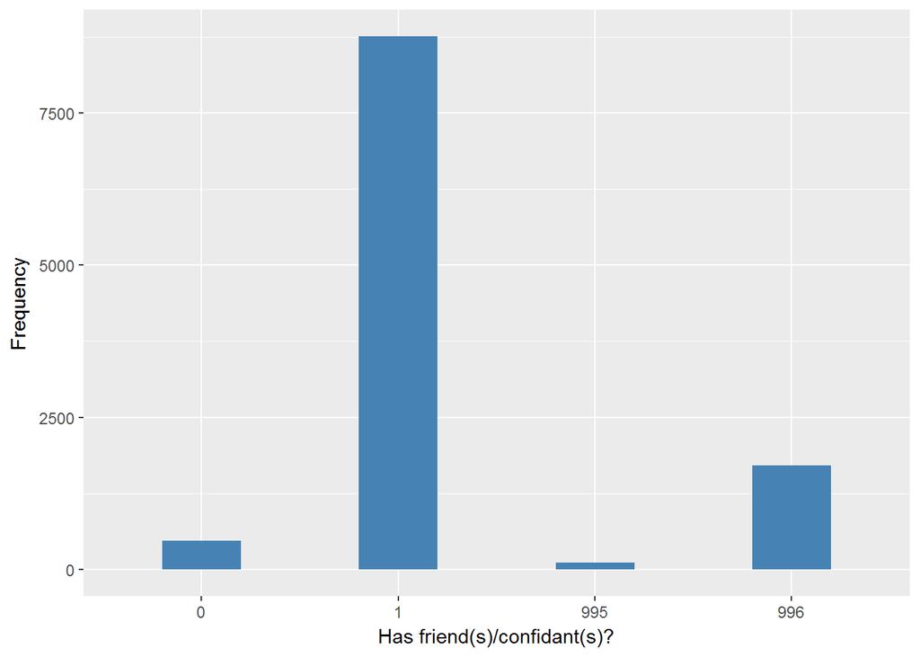

#### 2.1.4.4 Validation

|  | 2->0 | 1 | -9->995 | -1->996 |
| --- | --- | --- | --- | --- |
| BeforeH | 471 | 8756 | 115 | 1708 |
| AfterH | 471 | 8756 | 115 | 1708 |

### 2.1.5 Wave 5

#### 2.1.5.1 Study-specific variable description

- Name: `scfrd`
- Label: `Whether the respondent has any friends`
- Categories:
  - `1.0 = Yes`
  - `2.0 = No`
- Missings:
  - `-1.0 = Item not applicable`
  - `-2.0 = Schedule Not Applicable`
  - `-8.0 = Don't know`
  - `-9.0 = Not answered`
- Description:

| Sample size | Missing values |
| --- | --- |
| 10274 | 1360 |

Category

|  | 1 | 2 |
| --- | --- | --- |
| Frequency | 8382.00 | 532.00 |
| Percentage | 81.58 | 5.18 |

Type of missing

|  | -1 | -2 | -8 | -9 | NA |
| --- | --- | --- | --- | --- | --- |
| Frequency | 0 | 1244.00 | 0 | 116.00 | 0 |
| Percentage | 0 | 12.11 | 0 | 1.13 | 0 |

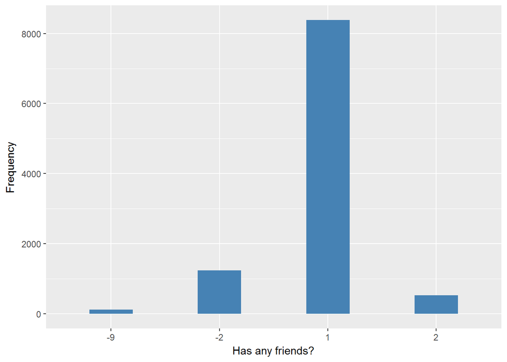

#### 2.1.5.2 Harmonisation algorithm

To recode the harmonize variable from the study-specific variable it has to be recoded as follows:

- `1 Yes into 1`
- `2 No into 0`
- `-1 Item not applicable into 996`
- `-2 Schedule Not Applicable into 996`
- `-8 Don't Know into 998`
- `-9 Not answered into 995`
- `NA into 999`

**R script:**

```r
ELSA_ds_w5 <- tibble(id = ELSA_w5_confidant$id)
ELSA_ds_w5$confidant <- car::recode(as.vector(ELSA_w5_confidant$scfrd), "1='1'; 2='0';-9='995'; -8='998'; -2='996'; -1='996'; NA='999'")
ELSA_ds_w5$confidant <- labelled(ELSA_ds_w5$confidant, labels = c(No = 0, Yes = 1,
    Missing = 999, `Do not know` = 998, Refuse = 997, `Not applicable` = 996,
    `Don't answer` = 995, `Not attempt/not done/not yet recorded` = 994, `Disable to measure` = 993,
    Impute = 992, `CAPI/interviewer error` = 991))
```

#### 2.1.5.3 Statistical description of the new harmonised variable

| Sample size | Missing values |
| --- | --- |
| 10274 | 1360 |

Category

|  | 0 | 1 |
| --- | --- | --- |
| Frequency | 532.00 | 8382.00 |
| Percentage | 5.18 | 81.58 |

Type of missing

|  | 991 | 992 | 993 | 994 | 995 | 996 | 997 | 998 | 999 | NA |
| --- | --- | --- | --- | --- | --- | --- | --- | --- | --- | --- |
| Frequency | 0 | 0 | 0 | 0 | 116.00 | 1244.00 | 0 | 0 | 0 | 0 |
| Percentage | 0 | 0 | 0 | 0 | 1.13 | 12.11 | 0 | 0 | 0 | 0 |

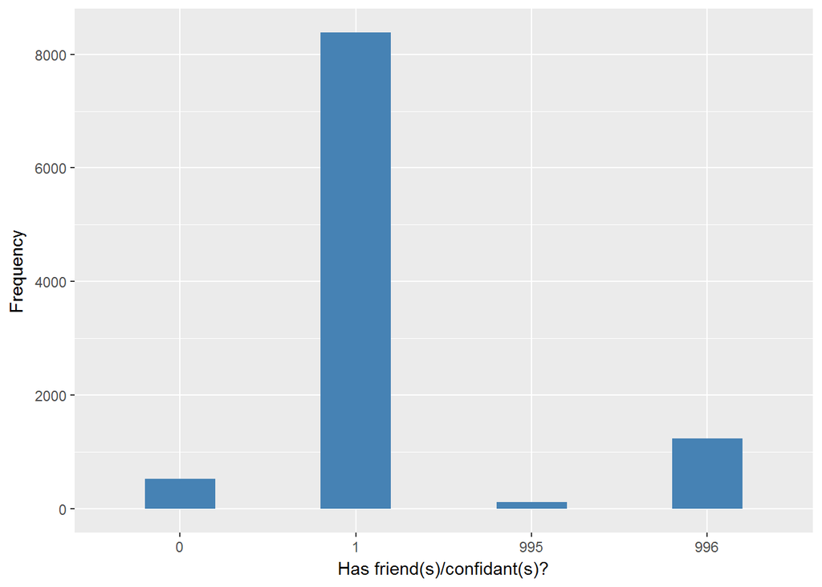

#### 2.1.5.4 Validation

|  | 2->0 | 1 | -9->995 | -2->996 |
| --- | --- | --- | --- | --- |
| BeforeH | 532 | 8382 | 116 | 1244 |
| AfterH | 532 | 8382 | 116 | 1244 |

### 2.1.6 Wave 6

#### 2.1.6.1 Study-specific variable description

- Name: `scfrd`
- Label: `Whether the respondent has any friends`
- Categories:
  - `1.0 = Yes`
  - `2.0 = No`
- Missings:
  - `-1.0 = Item not applicable`
  - `-2.0 = Schedule Not Applicable`
  - `-8.0 = Don't know`
  - `-9.0 = Not answered`
- Description:

| Sample size | Missing values |
| --- | --- |
| 10601 | 1656 |

Category

|  | 1 | 2 |
| --- | --- | --- |
| Frequency | 8383.00 | 562.0 |
| Percentage | 79.08 | 5.3 |

Type of missing

|  | -1 | -2 | -8 | -9 | NA |
| --- | --- | --- | --- | --- | --- |
| Frequency | 0 | 1604.00 | 0 | 52.00 | 0 |
| Percentage | 0 | 15.13 | 0 | 0.49 | 0 |

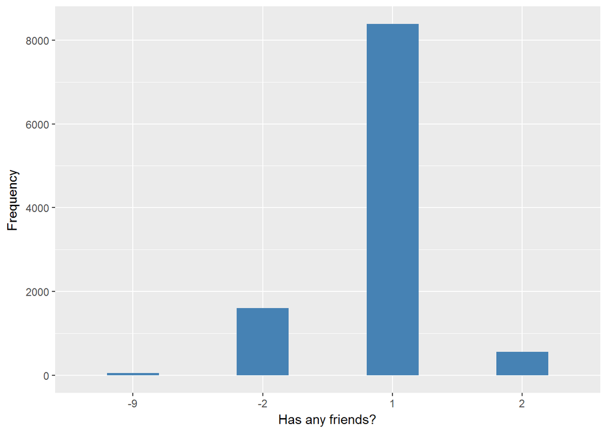

#### 2.1.6.2 Harmonisation algorithm

To recode the harmonize variable from the study-specific variable it has to be recoded as follows:

- `1 Yes into 1`
- `2 No into 0`
- `-1 Item not applicable into 996`
- `-2 Schedule Not Applicable into 996`
- `-8 Don't Know into 998`
- `-9 Not answered into 995`
- `NA into 999`

**R script:**

```r
ELSA_ds_w6 <- tibble(id = ELSA_w6_confidant$id)
ELSA_ds_w6$confidant <- car::recode(as.vector(ELSA_w6_confidant$scfrd), "1='1'; 2='0';-9='995'; -8='998'; -2='996'; -1='996'; NA='999'")
ELSA_ds_w6$confidant <- labelled(ELSA_ds_w6$confidant, labels = c(No = 0, Yes = 1,
    Missing = 999, `Do not know` = 998, Refuse = 997, `Not applicable` = 996,
    `Don't answer` = 995, `Not attempt/not done/not yet recorded` = 994, `Disable to measure` = 993,
    Impute = 992, `CAPI/interviewer error` = 991))
```

#### 2.1.6.3 Statistical description of the new harmonised variable

| Sample size | Missing values |
| --- | --- |
| 10601 | 1656 |

Category

|  | 0 | 1 |
| --- | --- | --- |
| Frequency | 562.0 | 8383.00 |
| Percentage | 5.3 | 79.08 |

Type of missing

|  | 991 | 992 | 993 | 994 | 995 | 996 | 997 | 998 | 999 | NA |
| --- | --- | --- | --- | --- | --- | --- | --- | --- | --- | --- |
| Frequency | 0 | 0 | 0 | 0 | 52.00 | 1604.00 | 0 | 0 | 0 | 0 |
| Percentage | 0 | 0 | 0 | 0 | 0.49 | 15.13 | 0 | 0 | 0 | 0 |

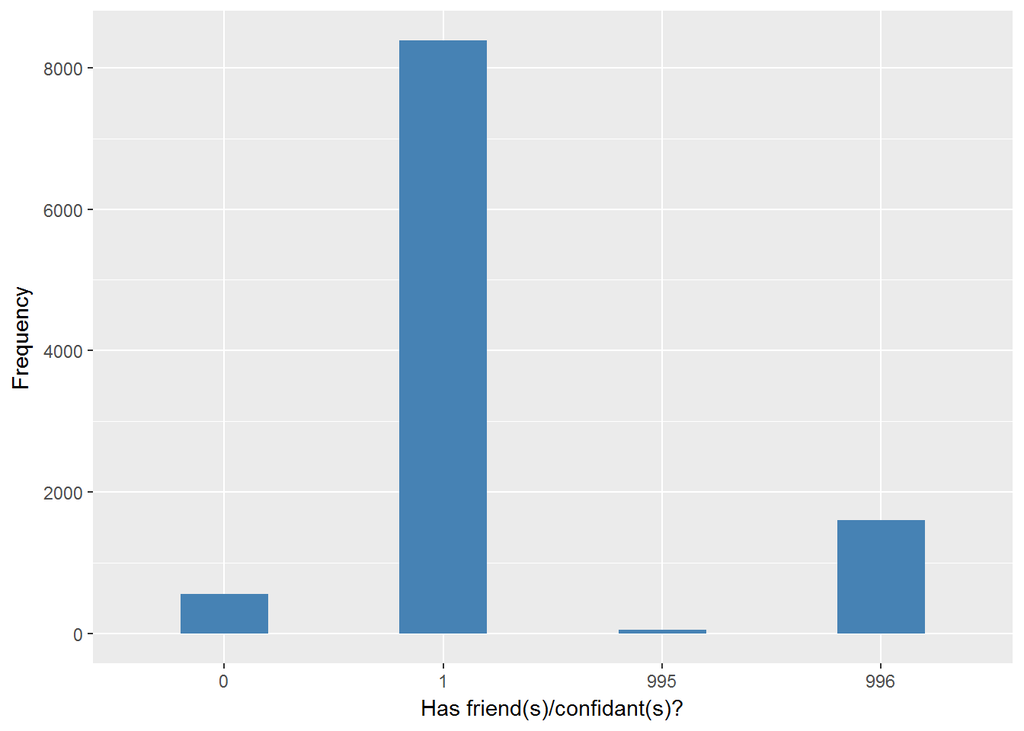

#### 2.1.6.4 Validation

|  | 2->0 | 1 | -9->995 | -2->996 |
| --- | --- | --- | --- | --- |
| BeforeH | 562 | 8383 | 52 | 1604 |
| AfterH | 562 | 8383 | 52 | 1604 |

### 2.1.7 Wave 7

#### 2.1.7.1 Study-specific variable description

- Name: `scfrd`
- Label: `Whether the respondent has any friends`
- Categories:
  - `1 = Yes`
  - `2 = No`
- Missings:
  - `-1 = Item not applicable`
  - `-2 = Schedule Not Applicable`
  - `-8 = Don't know`
  - `-9 = Not answered`
- Description:

| Sample size | Missing values |
| --- | --- |
| 9666 | 1542 |

Category

|  | 1 | 2 |
| --- | --- | --- |
| Frequency | 7620.00 | 504.00 |
| Percentage | 78.83 | 5.21 |

Type of missing

|  | -1 | -2 | -8 | -9 | NA |
| --- | --- | --- | --- | --- | --- |
| Frequency | 0 | 1469.0 | 0 | 73.00 | 0 |
| Percentage | 0 | 15.2 | 0 | 0.76 | 0 |

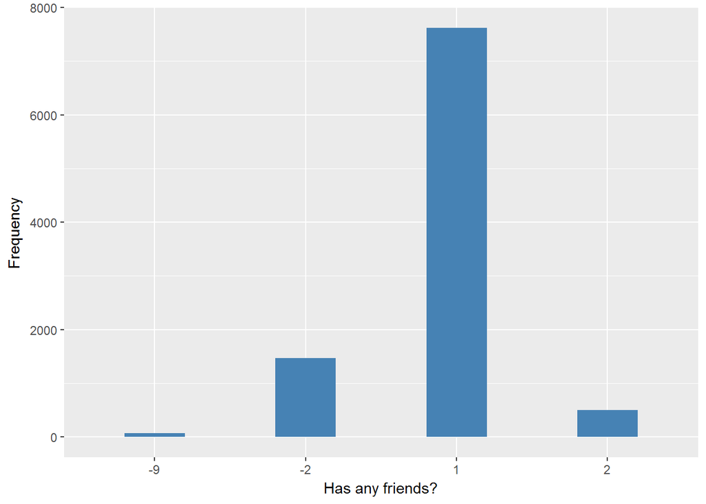

#### 2.1.7.2 Harmonisation algorithm

To recode the harmonize variable from the study-specific variable it has to be recoded as follows:

- `1 Yes into 1`
- `2 No into 0`
- `-1 Item not applicable into 996`
- `-2 Schedule Not Applicable into 996`
- `-8 Don't Know into 998`
- `-9 Not answered into 995`
- `NA into 999`

**R script:**

```r
ELSA_ds_w7 <- tibble(id = ELSA_w7$id)
ELSA_ds_w7$confidant <- car::recode(as.vector(ELSA_w7$scfrd), "1='1'; 2='0';-9='995'; -8='998'; -2='996'; -1='996'; NA='999'")
ELSA_ds_w7$confidant <- labelled(ELSA_ds_w7$confidant, labels = c(No = 0, Yes = 1,
    Missing = 999, `Do not know` = 998, Refuse = 997, `Not applicable` = 996,
    `Don't answer` = 995, `Not attempt/not done/not yet recorded` = 994, `Disable to measure` = 993,
    Impute = 992, `CAPI/interviewer error` = 991))
```

#### 2.1.7.3 Statistical description of the new harmonised variable

| Sample size | Missing values |
| --- | --- |
| 9666 | 1542 |

Category

|  | 0 | 1 |
| --- | --- | --- |
| Frequency | 504.00 | 7620.00 |
| Percentage | 5.21 | 78.83 |

Type of missing

|  | 991 | 992 | 993 | 994 | 995 | 996 | 997 | 998 | 999 | NA |
| --- | --- | --- | --- | --- | --- | --- | --- | --- | --- | --- |
| Frequency | 0 | 0 | 0 | 0 | 73.00 | 1469.0 | 0 | 0 | 0 | 0 |
| Percentage | 0 | 0 | 0 | 0 | 0.76 | 15.2 | 0 | 0 | 0 | 0 |

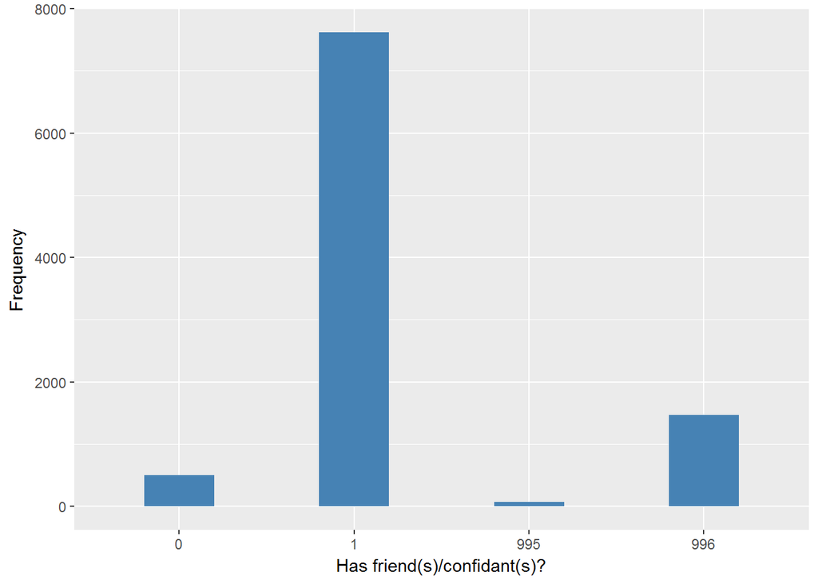

#### 2.1.7.4 Validation

|  | 2->0 | 1 | -9->995 | -2->996 |
| --- | --- | --- | --- | --- |
| BeforeH | 504 | 7620 | 73 | 1469 |
| AfterH | 504 | 7620 | 73 | 1469 |

# 3 Quality estimation